# Fitting Protein Synthesis Trajectories in Stan

## Plotting the data

And now we can plot our data:

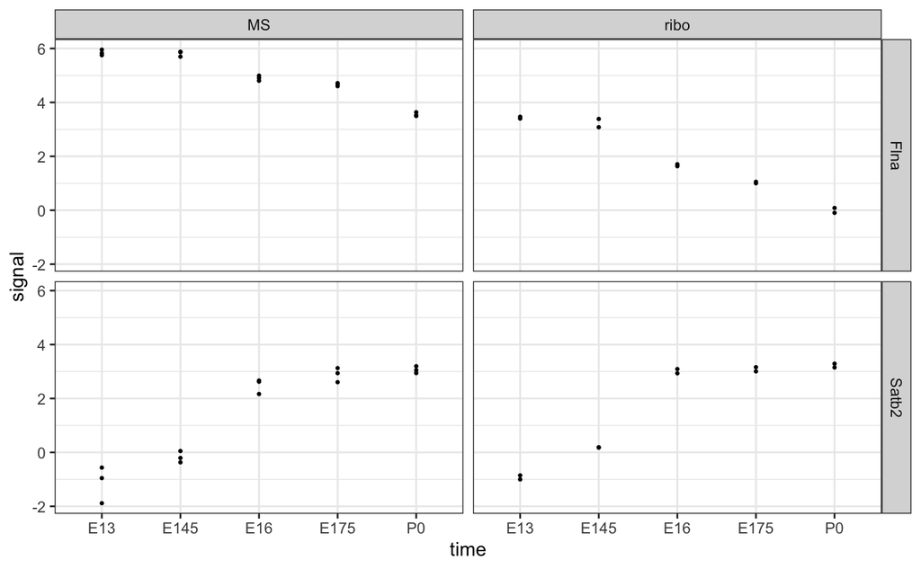

```r
meltmatrixdata <-function(x){x%>% {reshape2::melt(.)}%>%set_colnames(c('gene','dataset','signal'))%>%separate(dataset,c('time','assay','rep'))
}
id2name <- metainfo%>%distinct(uprotein_id,gene_name)%>%{setNames(.$gene_name,.$uprotein_id)}
msdata <- get_dp_standata(uids4stan[1:2])$lMS%>%meltmatrixdata
ribodata <- get_dp_standata(uids4stan[1:2])$lribo%>%meltmatrixdata
plotdata <- bind_rows(ribodata,msdata)
plotdata$gene <- id2name[as.character(plotdata$gene)]
qplot(data=plotdata,y=signal,x=time,geom='point',size=I(.5))+facet_grid(gene~assay)+theme_bw()
```

Note that these two genes, (called ‘Satb2’ and ‘Flna’) are of particular biological interest - they are known players in the biology of cortical development. The first has an increasing expression pattern that hopefully should pin down the degredation rate and the half life to some degree. The second shows interesting nonlinear behavior - the protein goes down more slowly than the Ribo-seq, indicating that degredation between timepoints is incomplete, and our nonlinear model should fit better.

# Model 1

```r
#set up stan
options(mc.cores = parallel::detectCores())
rstan_options(auto_write = TRUE)

#load the simplest model for single genes, but with dropout (our main model)
dp_stanfile = here('src/Stan/mod_proDD.stan')%T>%{stopifnot(file.exists(.))}
dp_model = rstan::stan_model(dp_stanfile)
```

The first model - dp_model, is what we discussed in our meeting, plus accounting for dropout. I got the dropout code from [here](https://github.com/const-ae/proDD/blob/master/src/stan_files/batch_skewed_posterior.stan).

Below you can see the mode code with commented parameters

```r
dp_model
```

```
S4 class stanmodel 'mod_proDD' coded as follows:
data {
  int nsamples;// number of samples
  int nribosamples;// number of samples
  int G;// number of proteins
  int T;// info on the number of conditions
  int totalmissing;// info on th total amount of missing data
  matrix[G, nsamples] lMS;// data
  matrix[G, nribosamples] lribo;// data
  matrix[G, nribosamples] ribo_sigma;
  int experimental_design[nsamples];// indicator variable matching the samples to conditions
  int experimental_design_r[nribosamples];
  real zeta[nsamples];// the spread of the dropout point for a library, gets combined with the varianc per protein
  real rho[nsamples];// rho the location of the dropout point for a given library
  real mu0;// fit by proDD the mean of means
  real sigma20;// fit by proDD - the variance in means
  real eta;// fit by proDD - th evariance in protein variances
  real nu;// fit by proDD - the mean of protein variances
  matrix[T,T+1] mybs; // spline basis for the protein trajectory
  matrix[T,T] mydbs; // differentiated spline basis for the RNA (piecewise linear right now)
  real l_st_priorsd;
  real l_ribo_priorsd;
  real l_ribo_priornu;
  real l_pihalf_priormu;
  real l_pihalf_priorsd;
}

parameters {
  real<lower=0> sigma2[G];// the variance for that protein
  vector<lower=-10,upper=10>[G] l_st; // the ratio of steady state ratio to ribo
  matrix<lower=-10,upper=10>[G,T] lsynths;  // log vector of fold changes due to synthesis
  vector<lower=-20,upper=20>[G] l_pihalf;  //log half life
  vector[G] prot0; // initial LOG amount of protein
}

transformed parameters{
    matrix [G,T] prot; // amounts of protein
    matrix [G,T] mRNA; // amounts of mRNA
    vector[G] Kd; // the degred
    vector[G] lKd; // the log degrad
```

[output cut: 52 more lines]

```
    for(i in 1:G){
      for(jr in 1:nribosamples){
        lribo[i,jr] ~ normal(mRNA[i,experimental_design_r[jr]], ribo_sigma[i,jr]); // use confidence intervals to weight the observations
      }
      for(j in 1:nsamples){
        if(is_inf(lMS[i, j])){
          target += normal_lccdf(prot[i, experimental_design[j]] | rho[j], fabs(zetastar[counter]));
          counter += 1;
        }else{
          lMS[i, j] ~ normal(prot[i, experimental_design[j]], sqrt(sigma2[i]));
        }
      }
    }
  }
}
```

### Technical parameters

So looking first at the bottom of the `model`….

```
  {
    int counter = 1;
    for(i in 1:G){
      for(jr in 1:nribosamples){
        lribo[i,jr] ~ normal(mRNA[i,experimental_design_r[jr]], ribo_sigma[i,jr]); // use confidence intervals to weight the observations
      }
      for(j in 1:nsamples){
        if(is_inf(lMS[i, j])){
          target += normal_lccdf(prot[i, experimental_design[j]] | rho[j], fabs(zetastar[counter]));
          counter += 1;
        }else{
          lMS[i, j] ~ normal(prot[i, experimental_design[j]], sqrt(sigma2[i]));
        }
      }
    }
  }
```

So for each gene, i in G, we are first predicting the (log2 of) Riboseq (ribo), which is normally distributed according with mean `mRNA` for each timepoint, the timepoint for each column being indexed by `experimental_design_r`, and having standard deviation `ribo_sigma` (note that this is experiment, not timepoint, specific).

Meanwhile the protein is either a dropout or not. If it’s a dropout (a value signified by -Inf) then, as with proDD, we fit the dropout likelihood using a sigmoid function, in this case normal_lccdf. If it’s not a dropout then it’s normally distributed. The mean expression `prot` is again indexed by a variable `experimental_design` for each timepoint. The variance of this normal distribution, which is gene specific, is denoted by `sigma2`.

Note that we can simply choose a gene without any dropouts and that part of the model won’t run.

### Kinetic Parameters

#### Theory

Ignoring the priors above this loop for a moment, The relationship between `prot` and `mRNA` is where the interesting part of the model is, and this relationship is descrbied in the `transformed parameters` block. The key is is the basic relationship (which I have awkwardly rendered in R code rather than latex):

```
'
#Basic mass action - P is synthesized at rate Ks from R and degraded at rate Kd
#P(t) and R(t) are functional forms (splines) for R and P
#dP is the P`, the differential over time
dP(t) = Ks*R(t) - Kd (P(t))
#re arrange this to isolate R
R(t) = dP(t) + Kd (P(t)) / Ks
#take the log
log(R(t)) = log(dP(t)+Kd*P(t)) - log(Ks)
#exploit the fact that P*log(P(t))`= P`(t)
log(R(t)) = log(P(t) * dlogP(t) +Kd*P(t)) - log(Ks)
#to get our log linear relationsihip
log(R(t)) = log(P(t)) + log(dlP(t) + Kd) - log(Ks)
```

This is kind of non ideal - we are assuming exponentail change between timepoints when linear is probably the simplest sassumption - but for now it’ll do! (The solution with linear space changes exists but I’m not quite happy with it yet)

Note that if Kd (the degredation rate) is high then dlP, the diffential of log P, doesn’t influece the above much and we find that the Riboseq is basical linear to the protein. If on the other P is low and Kd is also low, then log(R) is linear to the *change* in P. As expected. In practice the real situation is going to be somewhere in between these.

Note also that for high Kd and low dlP, Kd and Ks are not identifiable - an increase in Kd can be exactly cancelled by an increase in Ks. This is also as expected. Often, for this reason, these kinds of trajectories are parametrized not with Kd and Ks but with the half life (`log(2)/Kd`) and the steady state level - Ks/Kd. The latter is always identified, the former may not be, depending on the trajectory of R (which must deviate from an exponential decay curve) and the half life (which must be longer than the distance between time points).

#### Practice

We also need our model to be aware that the degredation can only be negative, and the synthesis can only be positive (i.e. `Kd` and `Ks` are both non negative). Since we want to go from a P trajectory to an R trajectory (differentiating is easier than integrating) we are then restricted in the possible combinations of parameters that make sense (note that in the above, dlP(t) + Kd(t) needs to be positive or we’re taking the log of a negative number). We can fix this by parametrizing dlP(t) + Kd directly. I call this value `synth`, as it is the the fold change due to synthesis, and necessariliy positive. The actual fold change in the protein is then `synth - Kd = fcs`. The fold change `fcs` and `synth` are time dependent and can be can be expressed as a spline, so from the above:

```
#let dB be the I spline basis of degree 1 (the identity matrix) and B be the corresponding I spline basis (it's integral)
#for simplicity we can assume that there's an extra column of 0s in dB and 1s in B, and append log(prot0) to our fcs.
#Then
dB %*% fcs = log'(P(t))
#and
B %*% fcs = log(P(t))
fcs  = synth - Kd (so m > Kd)
P'(t) = Ks (R(t)) - Kd P(t)
#Use logarithm derivative identity, substitute in our matrix
=) P'(t) = log'(P(t))*P(t) = log'(P(t))*exp(log(P(t))) = (dB %*% fcs ) exp (B%*%fcs)
#now put in our spline forms
=) (dB %*% fcs ) exp (B%*%fcs)  = Ks (R(t)) - Kd exp (B%*%fcs)
Ks (R(t)) =  (dB %*% m ) exp (B%*%m) +  Kd exp (B%*%m)
log(R(t)) = log( (dB %*% fcs ) exp (B%*%fcs) +  Kd exp (B%*%fcs)) - log(Ks)#tak the log, move Ks over
log(R(t)) = log( (dB %*% fcs ) +  Kd) + log(exp (B%*%fcs)) - log(Ks)#factorise and seperate form the log term
log(R(t)) = log(exp (B%*%fcs)) + log( (dB %*% fcs ) +  Kd) - log(Ks)

prot = log(P(t)) = B %*% fcs
log(R(t) = prot + log(dB %*% fcs + Kd) - log(Ks)
```

Which gets us a relatively neat parametrization of log(P) and log(R).

With that out of the way, we can explain how I’ve parametrized the model. We want our steady state level to be one parameter we sample from, since it’s always defined, and we want our half life to be the other. So the `transformed parameters` begins:

```
    #get Kd
    lKd = log2(log(2)) -  l_pihalf;
    Kd = exp(log(2)*lKd);

    //get pihalf
    lKs = l_st -  lKd;
```

Then we implement the above equations for log(P) (`prot`) and log(R) (`mRNA`)

```
    //get the fold changes due to synthesis (which must be positive)
    synth = exp(log(2)*lsynths);

    fcs = synth - rep_matrix( Kd,T);

    prot = append_col(prot0, fcs ) * (mybs)'; // get the full protein trajectory

    mRNA = prot + log2(synth * (mydbs)' ) - rep_matrix(lKs,T); // get the mRNA trajectory this implies
```

Finally we implement the sigmoid likelihood for dropouts as they do in proDD:

```
  {
    int counter = 1;
    for(i in 1:G){
      for(j in 1:nsamples){
        if(is_inf(lMS[i, j])){
          zetastar[counter] = zeta[j] * sqrt(1 + sigma2[i]/zeta[j]^2);
          counter = counter + 1;
        }
      }
    }
  }
```

### Deriving priors

Our model requires a number of prior parameters:

```
  sigma2 ~ scaled_inv_chi_square(nu, sqrt(eta));
  l_st ~ normal(0,l_st_priorsd);
  l_pihalf ~ normal(0,l_pihalf_priorsd);
  for(t in 1:T){
    lsynths[,t] ~ normal(0,l_ribo_priorsd);
  }// put a prior on fold changes
  prot0 ~ normal(mu0, sqrt(sigma20))
```

#### Half life prior

The prior for `pihalf` is tricker. Luckily, the literature comes to our rescue. We’ll use two papers to investigate the variance in protein half lives:

- 1 McShane et al
- 2 Schwannhauser et al

Let’s plot these data, and see how well they agree.

```r
library(here)
select=dplyr::select
schwandata<-suppressWarnings({readxl::read_excel(here('ext_data/schwannhauser_etal_2011_s3.xls'),sheet=1)})
schwangnames <- schwandata%>%select(gene_names=`Gene Names`)%>%mutate(gene_name=gene_names%>%str_split(';'))%>%mutate(n=1:n())%>%unnest(gene_name)

library(magrittr)
mcshanedf<-fread(here('ext_data/mcshane_etal_2016_S1.csv'))
mcshanethalfs<-mcshanedf%>%select(2,38,41)%>%set_colnames(c('gene_name','mcshane_half_life','McShane_deg_cat'))
mcshanethalfs$mcshane_half_life%<>%str_replace('> 300','300')%>%as.numeric

library(knitr)
inclusiontable<-function(a,b){
  all<-union(a,b)
  table(all%in%a,all%in%b)
}

kable(inclusiontable(mcshanedf$`Gene names`,schwangnames$gene_name),label = 'name overlap between tables')
```

|  | FALSE | TRUE |
| --- | --- | --- |
| FALSE | 0 | 7291 |
| TRUE | 594 | 2666 |

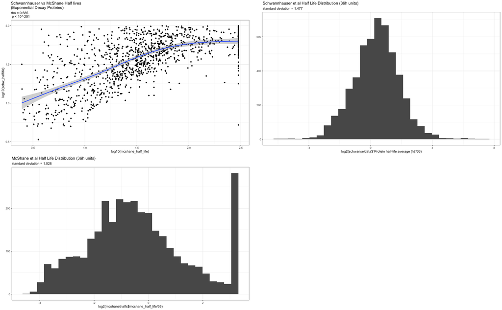

```r
schwanseldata <- schwandata%>%select(`Gene Names`,`Protein half-life average [h]`)
bothhalflifedata<-mcshanethalfs%>%inner_join(schwangnames,by=c('gene_name'='gene_name'))%>%
    cbind(.,schwanseldata[.$n,])

bothhalflifedata$schw_halflife <- bothhalflifedata$`Protein half-life average [h]`

thalfplot <- bothhalflifedata%>%
  filter(schw_halflife<100)%>%
  filter(McShane_deg_cat=='ED')%>%
  {qplot(data=.,x=log10(`mcshane_half_life`),y=log10(schw_halflife))+
      geom_smooth()+
      theme_bw()}

corlabel<-broom::tidy(bothhalflifedata%>%{cor.test(method='spearman',log10(.$schw_halflife),log10(.$mcshane_half_life))})%>%
  {str_interp('rho = ${round(.$estimate,3)}\n p < 10^${ceiling(log10(.$p.value))}')}


sddev = log2(schwanseldata$`Protein half-life average [h]`/36)%>%sd
sdlabel = paste0('standard deviation = ',round(sddev,3))
sddevmc = log2(mcshanethalfs$mcshane_half_life%>%.[.<300]%>%{./36})%>%sd
sdlabelmc = paste0('standard deviation = ',round(sddevmc,3))

ggpubr::ggarrange(plotlist=list(
  thalfplot+ggtitle('Schwannhauser vs McShane Half lives\n(Exponential Decay Proteins)',subtitle=corlabel),
  qplot(x = log2(schwanseldata$`Protein half-life average [h]`/36))+ggtitle('Schwannhauser et al Half Life Distribution (36h units)',subtitle=sdlabel)+theme_bw(),
  qplot(x = log2(mcshanethalfs$mcshane_half_life/36))+ggtitle('McShane et al Half Life Distribution (36h units)',subtitle=sdlabelmc)+theme_bw()
))
```

```r
NA
NA
```

Our time points are 36 hours apart, and our parameters are on a log2 scale, so if we do that conversation form their half lives in hours we get the above.

#### Fold change priors

Getting a prior for the fold changes due to synthesis is more difficult. Since changes due to synthesis in the protein are going to be less than changes in the Riboseq, we can get a weak prior by just asking how much the Ribo-seq changes

[figure not shown]

```r
library(MASS)
allmsfcs <- allstandata$lMS %>% {reshape2::melt(.)}%>%set_colnames(c('gene','dataset','signal'))%>%separate(dataset,c('time','assay','rep'))%>%group_by(gene,time)%>%summarise(signal=mean(signal[is.finite(signal)]))%>%summarise(fc = list(diff(signal)))%>%unnest(fc)

allribofcs <- allstandata$lribo %>% {reshape2::melt(.)}%>%set_colnames(c('gene','dataset','signal'))%>%separate(dataset,c('time','assay','rep'))%>%group_by(gene,time)%>%summarise(signal=mean(signal[is.finite(signal)]))%>%summarise(fc = list(diff(signal)))%>%unnest(fc)

# (allmsfcs$fc%>%{qplot(.)+ggtitle('MS fold change distribution',subtitle = sdlabel)+theme_bw()})
(allribofcs$fc%>%{qplot(.)+ggtitle('Ribo-seq fold change distribution',subtitle = sdlabel)+theme_bw()})
```

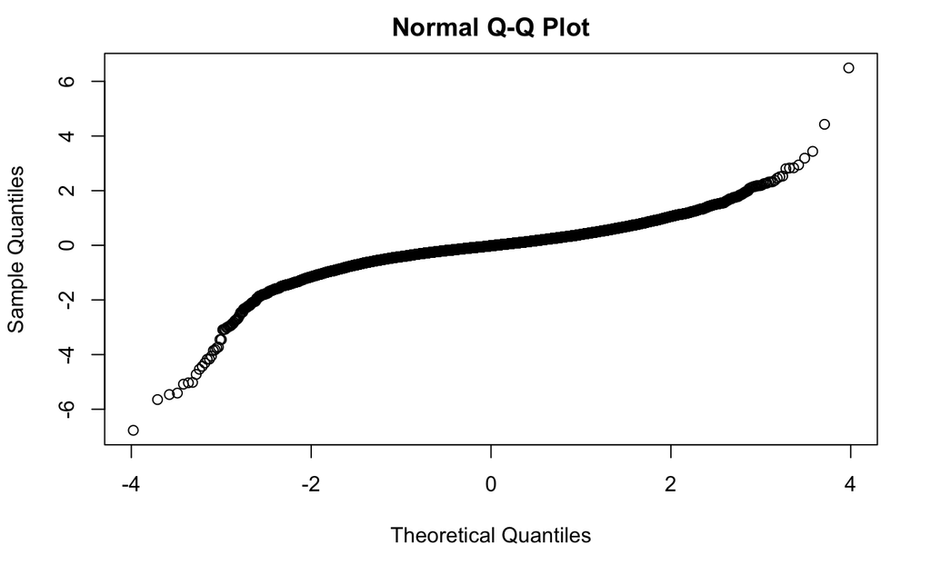

```r
fcvalues = allribofcs$fc

fcvalues_censor = allmsfcs$fc%>%na.omit%>%.[between(.,quantile(.,0.01),quantile(.,0.99))]

qqnorm(fcvalues)
```

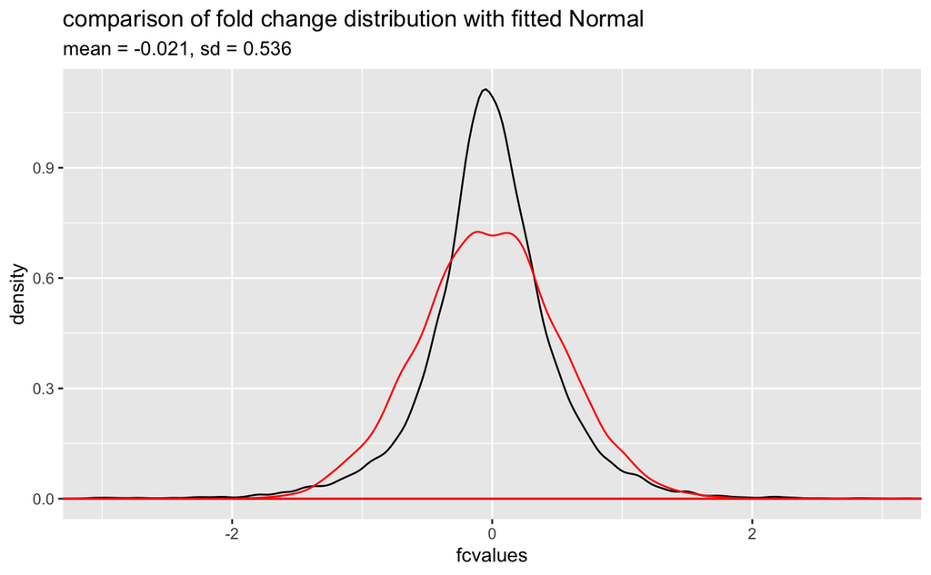

```r
normdistsample <- rnorm(1e4,mean=mean(fcvalues,na.rm=T),sd=sd(fcvalues,na.rm=T))
normallabel = str_interp("mean = ${round(mean(fcvalues,na.rm=T),3)}, sd = ${round(sd(fcvalues,na.rm=T),3)}")
ggplot(data=data.frame(fcvalues),aes(x=fcvalues))+geom_density()+geom_density(data=data.frame(fcvalues=normdistsample),color=I('red'))+coord_cartesian(xlim=c(-3,3))+
    ggtitle('comparison of fold change distribution with fitted Normal',subtitle = normallabel)
```